# Fish phylogenomics

```r
knitr::opts_chunk$set(echo = TRUE, warning = FALSE, message = FALSE)

library(ggplot2)
library(cowplot)
library(dplyr)
library(kableExtra)
library(tidyr)
library(ggtree)
library(phytools)
library(phangorn)
library(reshape2)
library(ggExtra)
library(ggrepel)
library(viridis)
library(ggdist)
library(stringr)
library(here)
source("../lib/design.r")
source("../lib/get_tree_info.r")
```

```r
#cat("188 species targeted capture to mouse exons assembled with SPADES.\n")
#cat("Pared to 109 species based on paring algorithm")
#cat("11,775 coding loci aligned with exonerate+mafft\n")
#cat("Gene trees inferred with IQtree.\n")

genome_file = here("data", "fish-genomes.csv")

tree_file = here("data", "astral-concord-rooted.tre")
absrel_file = here("data", "absrel.csv")

tree = read.tree(tree_file)
tree_to_df_list = treeToDF(tree)
tree_info = tree_to_df_list[["info"]]
tree_info = tree_info %>% separate(label, c("hyphy", "astral", "gcf", "scf"), sep="/", remove=F)

tree_info$astral[tree_info$node.type=="tip"] = NA
tree_info$astral = as.numeric(tree_info$astral)
tree_info$gcf = as.numeric(tree_info$gcf)

genomes = read.csv(genome_file, header=T)
names(genomes)[7] = "label"

tree_info = merge(tree_info, genomes, by="label", all=T)
tree_info = tree_info[order(tree_info$node), ]

absrel = read.csv(absrel_file, header=T, comment.char="#")
```

# 1 Methods summary

1. Retrieved CDS sequences based on protein IDs. Retained 3053 out of 3560 orthogroups.
2. Re-aligned with [Guidance](http://guidance.tau.ac.il/ver2/overview.php) to minimize further losses due to CDS/protein sequence mis-matches
3. Filtered alignments based on gappiness per sequence and per alignment column (window-based filter). Retained 2718 out of 3053 orthogroups.
4. Built gene trees from each of the 2718 orthogroups with [IQ-tree](http://www.iqtree.org/) and used them as input to ASTRAL to infer the species tree.
5. Assessed discordance between gene trees and species trees with [IQ-tree](http://www.iqtree.org/).
6. Inferred substitution rates and tested for selection per lineage with [HyPhy’s aBSREL test](http://www.hyphy.org/methods/selection-methods/). Used the species tree as input for all genes since discordance was low (see below). Corrected for multiple tests with the Bonferroni method (Original alpha was p < 0.01, corrected alpha is 3.679175864606328e-06).
7. Counted the number of times each branch showed evidence for positive selection (p < corrected alpha).

# 2 Genome info

We downloaded the genomes to convert from protein ID/sequence to CDS ID/sequence

```r
names(genomes)[7] = "Abbreviation"
genomes = select(genomes, -S.name, -Notes, -Sequencing.platform, -Assembly.method)
genomes %>% kable(caption="Fish genomes") %>% kable_styling(bootstrap_options=c("striped", "condensed", "responsive"), full_width=F)
```

Fish genomes

| Class | Order | Family | Species.name | Common.name | Abbreviation | NCBI.link | RefSeq.Accession | GenBank.Accession | Assembly.version | Ensembl.link | Other.links | Data.downloaded.from | Group | Coverage | Contigs | Contig.N50 | Scaffolds | Scaffold.N50 | Size..Mb. | Percent.GC |
| --- | --- | --- | --- | --- | --- | --- | --- | --- | --- | --- | --- | --- | --- | --- | --- | --- | --- | --- | --- | --- |
| Actinopterygii | Clupeiformes | Clupeidae | Alosa alosa | Allis shad | AALOS | https://www.ncbi.nlm.nih.gov/assembly/GCF_017589495.1/ | GCF_017589495.1 | GCA_017589495.2 | AALO_Geno_1.1 | NA | NA | RefSeq | GenoFish | 140 | 2631 | 1188980 | 1095 | 35353468 | 865.577 | 45.6945 |
| Actinopterygii | Clupeiformes | Clupeidae | Alosa sapidissima | American shad | ASAPD | https://www.ncbi.nlm.nih.gov/assembly/GCF_018492685.1 | GCF_018492685.1 | GCA_018492685.1 | fAloSap1.pri | NA | NA | RefSeq | Vertebrate Genomes Project | 33 | 1713 | 1565278 | 74 | 38440066 | 903.582 | 43.2182 |
| Actinopterygii | Osteoglossiformes | Osteoglossidae | Scleropages formosus | Asian bonytongue | SFORM | https://www.ncbi.nlm.nih.gov/assembly/GCF_900964775.1 | GCF_900964775.1 | GCA_900964775.1 | fSclFor1.1 | http://ftp.ensembl.org/pub/current_fasta/scleropages_formosus/ | NA | RefSeq | SC | 72 | 217 | 9102216 | 72 | 31084684 | 754.029 | 44.0572 |
| Actinopterygii | Gadiformes | Gadidae | Gadus morhua | Atlantic cod | GMORH | https://www.ncbi.nlm.nih.gov/assembly/GCF_902167405.1 | GCF_902167405.1 | GCA_902167405.1 | gadMor3.0 | http://ftp.ensembl.org/pub/current_fasta/gadus_morhua/ | NA | RefSeq | SC | 83 | 1442 | 1015663 | 227 | 28732775 | 627.043 | 45.8019 |
| Actinopterygii | Clupeiformes | Denticipitidae | Denticeps clupeoides | Denticle herring | DCLUP | https://www.ncbi.nlm.nih.gov/assembly/GCA_900700375.1/ | GCF_900700375.1 | GCA_900700375.1 | fDenClu1.1 | http://ftp.ensembl.org/pub/current_fasta/denticeps_clupeoides/ | NA | RefSeq | SC | 63 | 924 | 3059612 | 460 | 22793177 | 512.553 | 43.6220 |
| Actinopterygii | Clupeiformes | Clupeidae | Clupea harengus | Atlantic herring | CHARE | https://www.ncbi.nlm.nih.gov/assembly/GCF_900700415.2 | GCF_900700415.2 | GCA_900700415.2 | Ch_v2.0.2 | http://ftp.ensembl.org/pub/current_fasta/clupea_harengus/ | NA | RefSeq | UPPSALA UNIVERISTY | 75 | 3714 | 1006413 | 1724 | 29845739 | 790.024 | 44.3314 |
| Actinopterygii | Clupeiformes | Clupeidae | Sardina pilchardus | European sardine | SPILC | https://www.ncbi.nlm.nih.gov/assembly/GCA_900499035.1/ | NA | GCA_900499035.1 | SP_G | NA | http://gigadb.org/dataset/view/id/100596/Sample_page/2 | GigaDB | CCMAR | 50 | 194510 | 9398 | 117259 | 96617 | 795.554 | 44.4000 |

# 3 Species tree and gene concordance factors

All branches except the one leading to Node4 have gCF > 95, indicating very high concordance between gene and species trees.

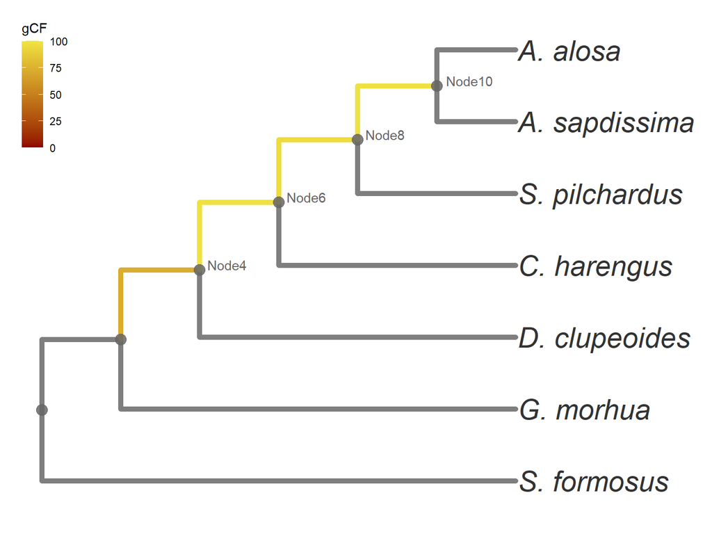

```r
h = corecol(numcol=1, pal="wilke", offset=3)
l = corecol(numcol=1, offset=3)
# Colors

xmax = 8

gcf_tree = ggtree(tree, size=2, ladderize=T, aes(color=tree_info$gcf)) +
  scale_color_continuous(name='gCF', low=l, high=h, limits=c(0,100)) +
  xlim(0, xmax) +
  geom_tiplab(aes(label=tree_info$S.name), color="#333333", fontface='italic', size=8) +
  geom_text(aes(label=ifelse(tree_info$node.type=="internal" & tree_info$hyphy!="20",tree_info$hyphy, '')), hjust=-.2, vjust=-.0, color="#666666") +
  geom_nodepoint(color="#666666", alpha=0.85, size=4) +
  theme(legend.position=c(0.05,0.85))
print(gcf_tree)
```

```r
###############
## gCF tree
```

# 4 Number of genes with evidence for selection per branch (aBSREL)

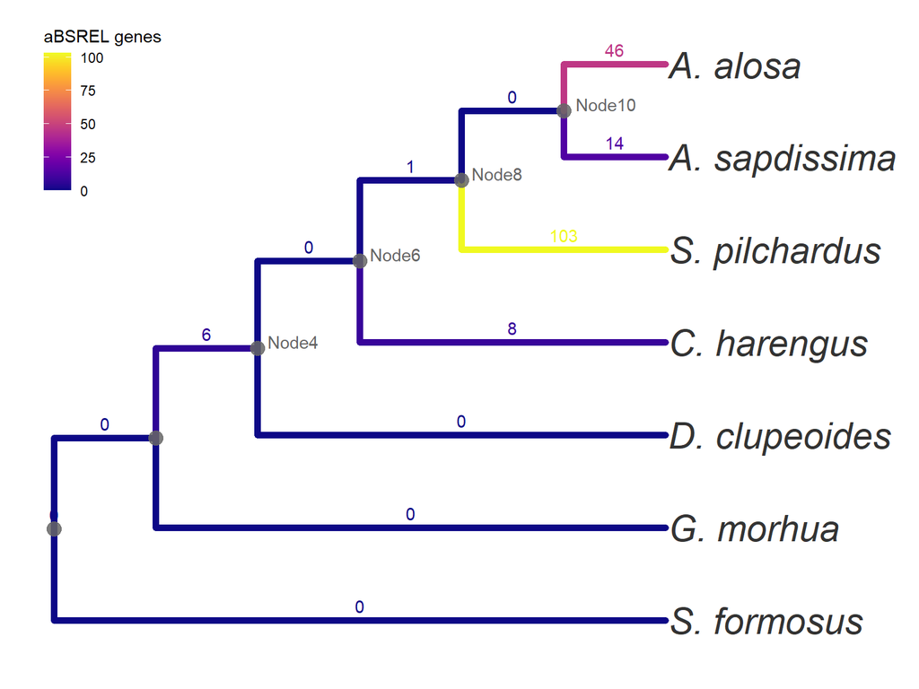

```r
absrel_counts = data.frame("hyphy"=tree_info$hyphy, "count"=c(0,0,0,0,0,0,0,0,0,0,0,0,0))
# Data frame for counts per branch


for(i in 1:nrow(absrel)){
  cur_branches = absrel[i,]$branches.pval.less.than.alpha
  if(cur_branches == ""){
    next
  }
  cur_branches = strsplit(cur_branches, ";")
  for(branch in cur_branches){
    absrel_counts[absrel_counts$hyphy==branch,]$count = absrel_counts[absrel_counts$hyphy==branch,]$count + 1
  }
}
# Loop over every row in the absrel data frame (every gene) and parse out the branches with evidence for selection

tree_info_counts = merge(tree_info, absrel_counts, by="hyphy")
tree_info_counts = tree_info_counts[order(tree_info_counts$node), ]
# Merge the tree and absrel data frames and re-sort by ape node so the trees still work

h = corecol(numcol=1, pal="wilke", offset=3)
l = corecol(numcol=1, offset=3)
# Colors

xmax = 8

absrel_tree = ggtree(tree, size=2, ladderize=T, aes(color=tree_info_counts$count)) +
  #scale_color_continuous(name='aBSREL genes', low=l, high=h) +
  scale_color_viridis(name='aBSREL genes', option = "C") +
  xlim(0, xmax) +
  geom_tiplab(aes(label=tree_info$S.name), color="#333333", fontface='italic', size=8) +
  geom_text(aes(label=ifelse(tree_info$node.type=="internal" & tree_info$hyphy!="20",tree_info$hyphy, '')), hjust=-.2, vjust=-.0, color="#666666") +
  geom_label(aes(x=branch, label=tree_info_counts$count), label.size=NA, fill="transparent", show.legend=F, vjust=-0.1) +
  geom_nodepoint(color="#666666", alpha=0.85, size=4) +
  theme(legend.position=c(0.1,0.85))

print(absrel_tree)
```

```r
###############
## absrel tree

absrel_counts = subset(absrel_counts, hyphy != "20")
absrel_counts = subset(absrel_counts, hyphy != "")
names(absrel_counts) = c("Node label", "# of genes with evidence for selection")

absrel_counts %>% kable(caption="aBSREL genes") %>% kable_styling(bootstrap_options=c("striped", "condensed", "responsive"), full_width=F)
```

aBSREL genes

|  | Node label | # of genes with evidence for selection |
| --- | --- | --- |
| 1 | SFORM | 0 |
| 2 | DCLUP | 0 |
| 3 | CHARE | 8 |
| 4 | SPILC | 103 |
| 5 | ASAPD | 14 |
| 6 | AALOS | 46 |
| 7 | GMORH | 0 |
| 10 | Node4 | 6 |
| 11 | Node6 | 0 |
| 12 | Node8 | 1 |
| 13 | Node10 | 0 |